# examples_0406

A polynomial is sketched below.

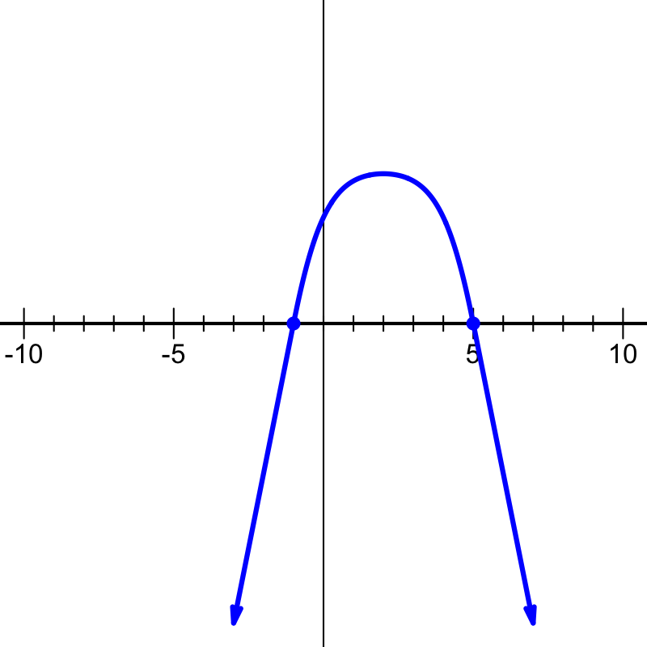

Which polynomial (in factored form) best matches the sketch?

$y=-(x-5)(x+1)$$y=(x-5)(x+1)$$y=(x+5)(x-1)$$y=-(x+5)(x-1)$

If a polynomial has a factor of $(x-r)$, then there will be an $x$-intercept at $(r,0)$.

In this case, the roots (the $x$-intercepts) are at:

$$-1,\,5$$

Thus, the factors are $x+1$ and $x-5$. So, we know that the function could be written as:

$$y=a(x+1)(x-5)$$

where $a$ is some constant.

Lastly, we need to determine whether $a$ should be positive or negative. In this problem, either $a=1$ or $a=-1$. To determine this, look at the right side of the graph. Specifically, we are considering the [end behavior of polynomials](https://www.khanacademy.org/math/algebra2/x2ec2f6f830c9fb89:poly-graphs/x2ec2f6f830c9fb89:poly-end-behavior/a/end-behavior-of-polynomials). Notice that once $x$ is larger than $5$, all the factors will be positive, so only $a$ will dictate whether the function on the right side is positive or negative.

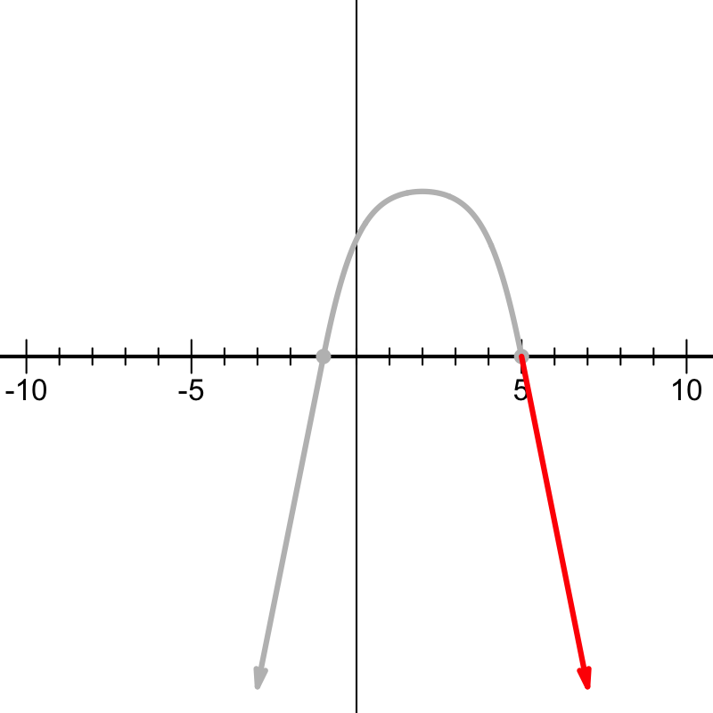

Notice, on the right side, the function is heading down. I guess more importantly, as $x\to \infty$ we see the function is negative. This implies that $a$ is negative. So, in this case, $a=-1$.

$$y=-(x+1)(x-5)$$

And then, since multiplication is commutative, the factors can be written in any order. In this case, the correct answer is:

$$y=-(x-5)(x+1)$$

A polynomial is sketched below.

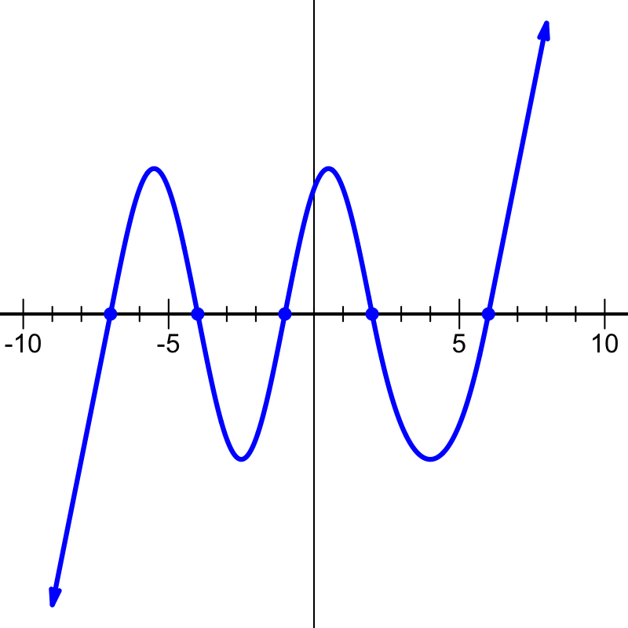

Which polynomial (in factored form) best matches the sketch?

$y=-(x+2)(x-4)(x+6)(x-7)(x-1)$$y=(x-2)(x+4)(x-6)(x+7)(x+1)$$y=-(x-2)(x+4)(x-6)(x+7)(x+1)$$y=(x+2)(x-4)(x+6)(x-7)(x-1)$

If a polynomial has a factor of $(x-r)$, then there will be an $x$-intercept at $(r,0)$.

In this case, the roots (the $x$-intercepts) are at:

$$-7,\,-4,\,-1,\,2,\,6$$

Thus, the factors are $x+7$ and $x+4$ and $x+1$ and $x-2$ and $x-6$. So, we know that the function could be written as:

$$y=a(x+7)(x+4)(x+1)(x-2)(x-6)$$

where $a$ is some constant.

Lastly, we need to determine whether $a$ should be positive or negative. In this problem, either $a=1$ or $a=-1$. To determine this, look at the right side of the graph. Specifically, we are considering the [end behavior of polynomials](https://www.khanacademy.org/math/algebra2/x2ec2f6f830c9fb89:poly-graphs/x2ec2f6f830c9fb89:poly-end-behavior/a/end-behavior-of-polynomials). Notice that once $x$ is larger than $6$, all the factors will be positive, so only $a$ will dictate whether the function on the right side is positive or negative.

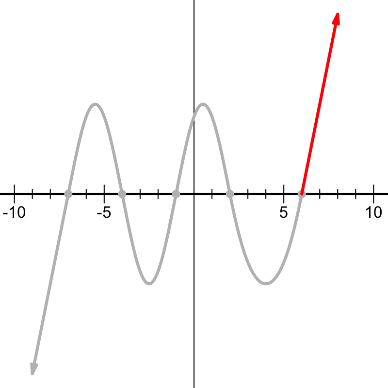

Notice, on the right side, the function is heading up. I guess more importantly, as $x\to \infty$ we see the function is positive. This implies that $a$ is positive. So, in this case, $a=1$.

$$y=(x+7)(x+4)(x+1)(x-2)(x-6)$$

And then, since multiplication is commutative, the factors can be written in any order. In this case, the correct answer is:

$$y=(x-2)(x+4)(x-6)(x+7)(x+1)$$

A polynomial is sketched below.

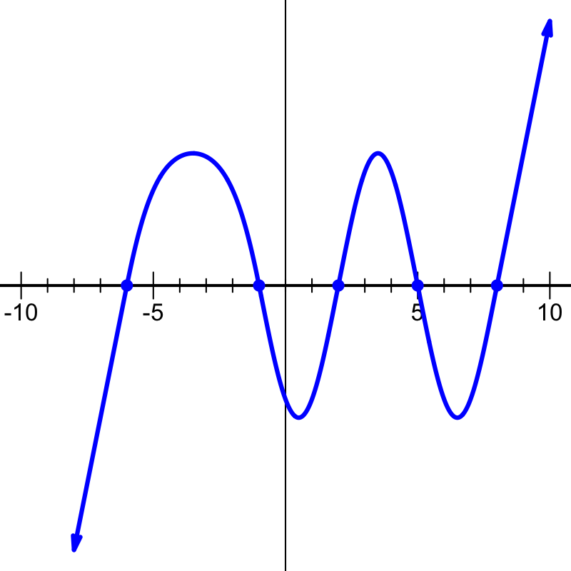

Which polynomial (in factored form) best matches the sketch?

$y=(x-8)(x-5)(x+6)(x+1)(x-2)$$y=-(x+8)(x+5)(x-6)(x-1)(x+2)$$y=-(x-8)(x-5)(x+6)(x+1)(x-2)$$y=(x+8)(x+5)(x-6)(x-1)(x+2)$

If a polynomial has a factor of $(x-r)$, then there will be an $x$-intercept at $(r,0)$.

In this case, the roots (the $x$-intercepts) are at:

$$-6,\,-1,\,2,\,5,\,8$$

Thus, the factors are $x+6$ and $x+1$ and $x-2$ and $x-5$ and $x-8$. So, we know that the function could be written as:

$$y=a(x+6)(x+1)(x-2)(x-5)(x-8)$$

where $a$ is some constant.

Lastly, we need to determine whether $a$ should be positive or negative. In this problem, either $a=1$ or $a=-1$. To determine this, look at the right side of the graph. Specifically, we are considering the [end behavior of polynomials](https://www.khanacademy.org/math/algebra2/x2ec2f6f830c9fb89:poly-graphs/x2ec2f6f830c9fb89:poly-end-behavior/a/end-behavior-of-polynomials). Notice that once $x$ is larger than $8$, all the factors will be positive, so only $a$ will dictate whether the function on the right side is positive or negative.

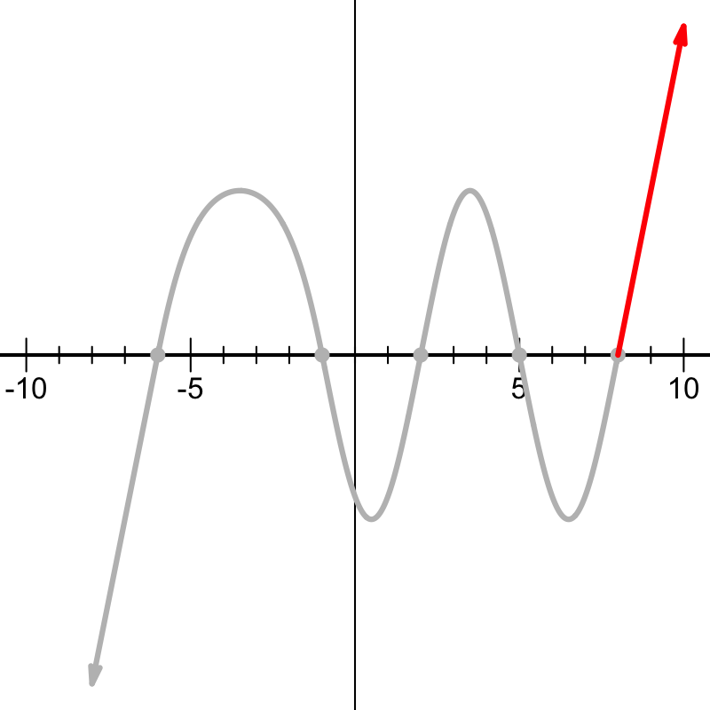

Notice, on the right side, the function is heading up. I guess more importantly, as $x\to \infty$ we see the function is positive. This implies that $a$ is positive. So, in this case, $a=1$.

$$y=(x+6)(x+1)(x-2)(x-5)(x-8)$$

And then, since multiplication is commutative, the factors can be written in any order. In this case, the correct answer is:

$$y=(x-8)(x-5)(x+6)(x+1)(x-2)$$

A polynomial is sketched below.

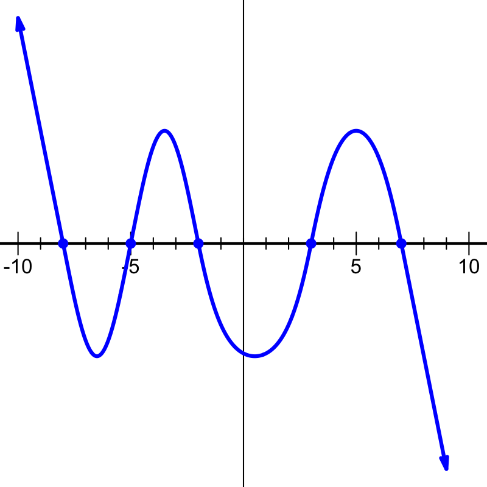

Which polynomial (in factored form) best matches the sketch?

$y=(x-5)(x+3)(x-2)(x+7)(x-8)$$y=-(x+5)(x-3)(x+2)(x-7)(x+8)$$y=-(x-5)(x+3)(x-2)(x+7)(x-8)$$y=(x+5)(x-3)(x+2)(x-7)(x+8)$

If a polynomial has a factor of $(x-r)$, then there will be an $x$-intercept at $(r,0)$.

In this case, the roots (the $x$-intercepts) are at:

$$-8,\,-5,\,-2,\,3,\,7$$

Thus, the factors are $x+8$ and $x+5$ and $x+2$ and $x-3$ and $x-7$. So, we know that the function could be written as:

$$y=a(x+8)(x+5)(x+2)(x-3)(x-7)$$

where $a$ is some constant.

Lastly, we need to determine whether $a$ should be positive or negative. In this problem, either $a=1$ or $a=-1$. To determine this, look at the right side of the graph. Specifically, we are considering the [end behavior of polynomials](https://www.khanacademy.org/math/algebra2/x2ec2f6f830c9fb89:poly-graphs/x2ec2f6f830c9fb89:poly-end-behavior/a/end-behavior-of-polynomials). Notice that once $x$ is larger than $7$, all the factors will be positive, so only $a$ will dictate whether the function on the right side is positive or negative.

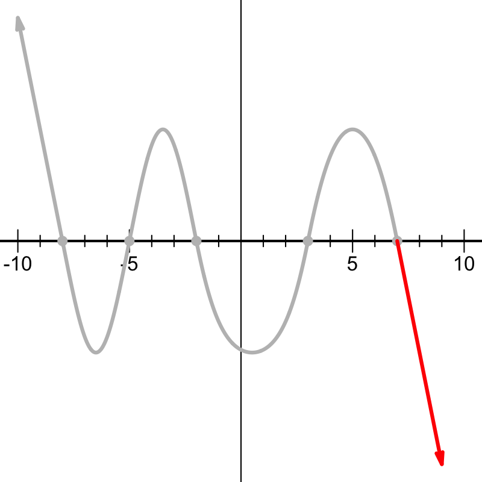

Notice, on the right side, the function is heading down. I guess more importantly, as $x\to \infty$ we see the function is negative. This implies that $a$ is negative. So, in this case, $a=-1$.

$$y=-(x+8)(x+5)(x+2)(x-3)(x-7)$$

And then, since multiplication is commutative, the factors can be written in any order. In this case, the correct answer is:

$$y=-(x+5)(x-3)(x+2)(x-7)(x+8)$$

A polynomial is sketched below.

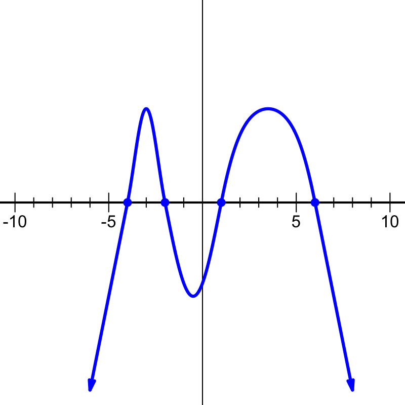

Which polynomial (in factored form) best matches the sketch?

$y=(x+6)(x+1)(x-4)(x-2)$$y=-(x+6)(x+1)(x-4)(x-2)$$y=(x-6)(x-1)(x+4)(x+2)$$y=-(x-6)(x-1)(x+4)(x+2)$

If a polynomial has a factor of $(x-r)$, then there will be an $x$-intercept at $(r,0)$.

In this case, the roots (the $x$-intercepts) are at:

$$-4,\,-2,\,1,\,6$$

Thus, the factors are $x+4$ and $x+2$ and $x-1$ and $x-6$. So, we know that the function could be written as:

$$y=a(x+4)(x+2)(x-1)(x-6)$$

where $a$ is some constant.

Lastly, we need to determine whether $a$ should be positive or negative. In this problem, either $a=1$ or $a=-1$. To determine this, look at the right side of the graph. Specifically, we are considering the [end behavior of polynomials](https://www.khanacademy.org/math/algebra2/x2ec2f6f830c9fb89:poly-graphs/x2ec2f6f830c9fb89:poly-end-behavior/a/end-behavior-of-polynomials). Notice that once $x$ is larger than $6$, all the factors will be positive, so only $a$ will dictate whether the function on the right side is positive or negative.

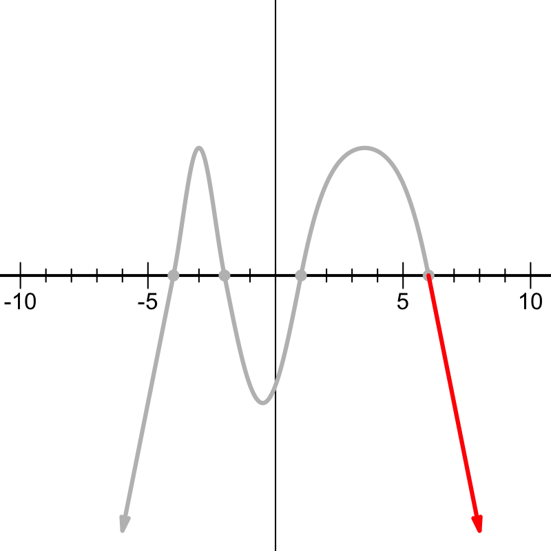

Notice, on the right side, the function is heading down. I guess more importantly, as $x\to \infty$ we see the function is negative. This implies that $a$ is negative. So, in this case, $a=-1$.

$$y=-(x+4)(x+2)(x-1)(x-6)$$

And then, since multiplication is commutative, the factors can be written in any order. In this case, the correct answer is:

$$y=-(x-6)(x-1)(x+4)(x+2)$$

A polynomial is sketched below.

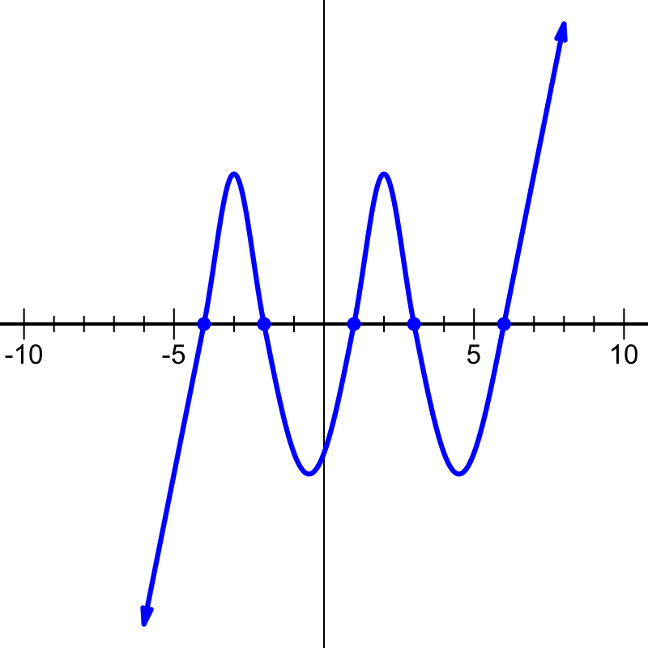

Which polynomial (in factored form) best matches the sketch?

$y=-(x+4)(x+2)(x-3)(x-1)(x-6)$$y=-(x-4)(x-2)(x+3)(x+1)(x+6)$$y=(x-4)(x-2)(x+3)(x+1)(x+6)$$y=(x+4)(x+2)(x-3)(x-1)(x-6)$

If a polynomial has a factor of $(x-r)$, then there will be an $x$-intercept at $(r,0)$.

In this case, the roots (the $x$-intercepts) are at:

$$-4,\,-2,\,1,\,3,\,6$$

Thus, the factors are $x+4$ and $x+2$ and $x-1$ and $x-3$ and $x-6$. So, we know that the function could be written as:

$$y=a(x+4)(x+2)(x-1)(x-3)(x-6)$$

where $a$ is some constant.

Lastly, we need to determine whether $a$ should be positive or negative. In this problem, either $a=1$ or $a=-1$. To determine this, look at the right side of the graph. Specifically, we are considering the [end behavior of polynomials](https://www.khanacademy.org/math/algebra2/x2ec2f6f830c9fb89:poly-graphs/x2ec2f6f830c9fb89:poly-end-behavior/a/end-behavior-of-polynomials). Notice that once $x$ is larger than $6$, all the factors will be positive, so only $a$ will dictate whether the function on the right side is positive or negative.

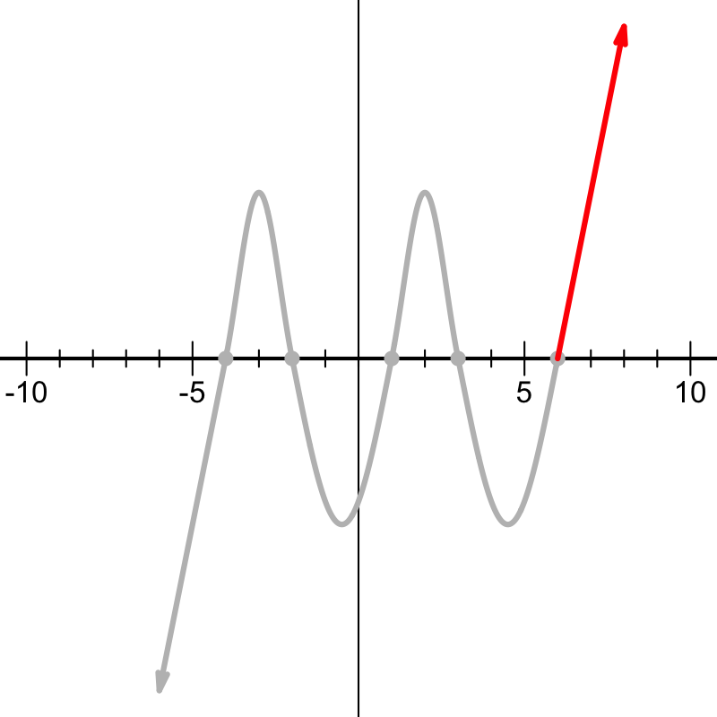

Notice, on the right side, the function is heading up. I guess more importantly, as $x\to \infty$ we see the function is positive. This implies that $a$ is positive. So, in this case, $a=1$.

$$y=(x+4)(x+2)(x-1)(x-3)(x-6)$$

And then, since multiplication is commutative, the factors can be written in any order. In this case, the correct answer is:

$$y=(x+4)(x+2)(x-3)(x-1)(x-6)$$

A polynomial is sketched below.

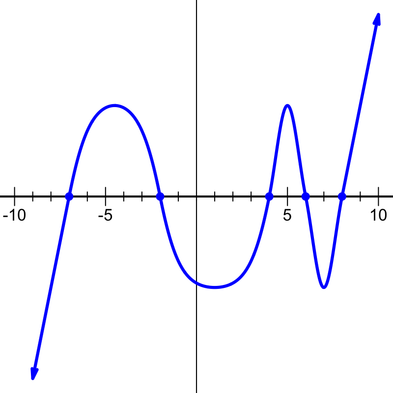

Which polynomial (in factored form) best matches the sketch?

$y=(x+7)(x-6)(x-4)(x+2)(x-8)$$y=-(x+7)(x-6)(x-4)(x+2)(x-8)$$y=-(x-7)(x+6)(x+4)(x-2)(x+8)$$y=(x-7)(x+6)(x+4)(x-2)(x+8)$

If a polynomial has a factor of $(x-r)$, then there will be an $x$-intercept at $(r,0)$.

In this case, the roots (the $x$-intercepts) are at:

$$-7,\,-2,\,4,\,6,\,8$$

Thus, the factors are $x+7$ and $x+2$ and $x-4$ and $x-6$ and $x-8$. So, we know that the function could be written as:

$$y=a(x+7)(x+2)(x-4)(x-6)(x-8)$$

where $a$ is some constant.

Lastly, we need to determine whether $a$ should be positive or negative. In this problem, either $a=1$ or $a=-1$. To determine this, look at the right side of the graph. Specifically, we are considering the [end behavior of polynomials](https://www.khanacademy.org/math/algebra2/x2ec2f6f830c9fb89:poly-graphs/x2ec2f6f830c9fb89:poly-end-behavior/a/end-behavior-of-polynomials). Notice that once $x$ is larger than $8$, all the factors will be positive, so only $a$ will dictate whether the function on the right side is positive or negative.

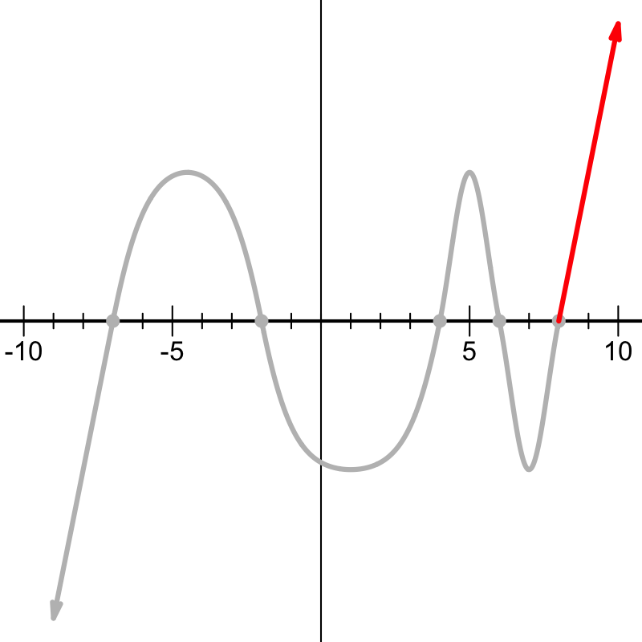

Notice, on the right side, the function is heading up. I guess more importantly, as $x\to \infty$ we see the function is positive. This implies that $a$ is positive. So, in this case, $a=1$.

$$y=(x+7)(x+2)(x-4)(x-6)(x-8)$$

And then, since multiplication is commutative, the factors can be written in any order. In this case, the correct answer is:

$$y=(x+7)(x-6)(x-4)(x+2)(x-8)$$

A polynomial is sketched below.

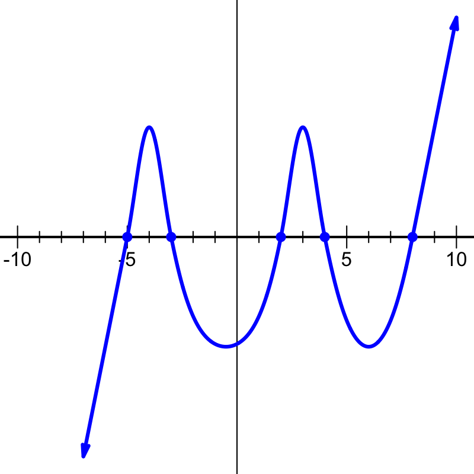

Which polynomial (in factored form) best matches the sketch?

$y=(x-8)(x-4)(x+5)(x+3)(x-2)$$y=-(x-8)(x-4)(x+5)(x+3)(x-2)$$y=(x+8)(x+4)(x-5)(x-3)(x+2)$$y=-(x+8)(x+4)(x-5)(x-3)(x+2)$

If a polynomial has a factor of $(x-r)$, then there will be an $x$-intercept at $(r,0)$.

In this case, the roots (the $x$-intercepts) are at:

$$-5,\,-3,\,2,\,4,\,8$$

Thus, the factors are $x+5$ and $x+3$ and $x-2$ and $x-4$ and $x-8$. So, we know that the function could be written as:

$$y=a(x+5)(x+3)(x-2)(x-4)(x-8)$$

where $a$ is some constant.

Lastly, we need to determine whether $a$ should be positive or negative. In this problem, either $a=1$ or $a=-1$. To determine this, look at the right side of the graph. Specifically, we are considering the [end behavior of polynomials](https://www.khanacademy.org/math/algebra2/x2ec2f6f830c9fb89:poly-graphs/x2ec2f6f830c9fb89:poly-end-behavior/a/end-behavior-of-polynomials). Notice that once $x$ is larger than $8$, all the factors will be positive, so only $a$ will dictate whether the function on the right side is positive or negative.

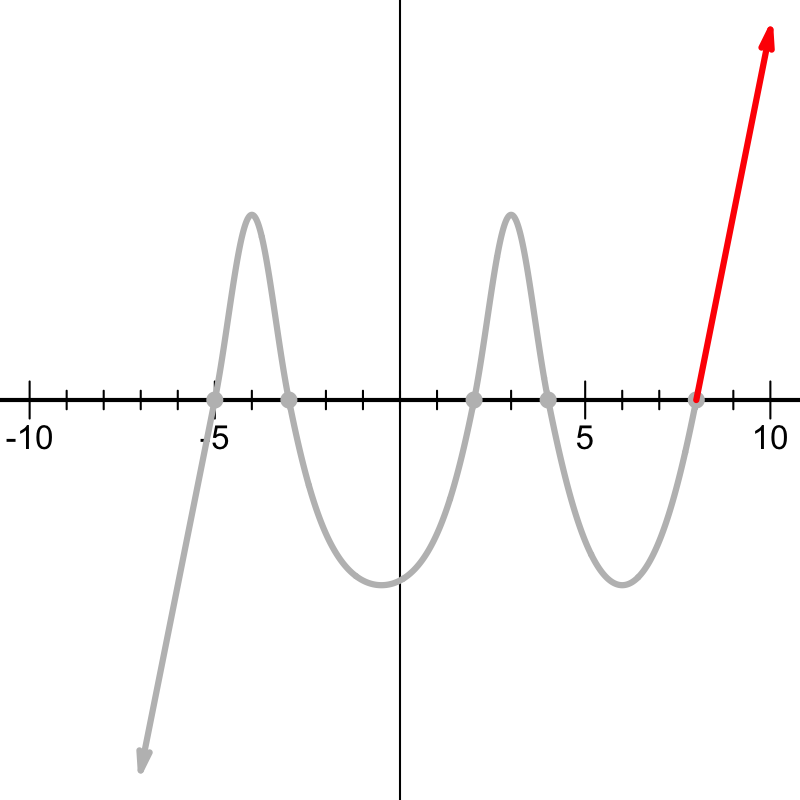

Notice, on the right side, the function is heading up. I guess more importantly, as $x\to \infty$ we see the function is positive. This implies that $a$ is positive. So, in this case, $a=1$.

$$y=(x+5)(x+3)(x-2)(x-4)(x-8)$$

And then, since multiplication is commutative, the factors can be written in any order. In this case, the correct answer is:

$$y=(x-8)(x-4)(x+5)(x+3)(x-2)$$

A polynomial is sketched below.

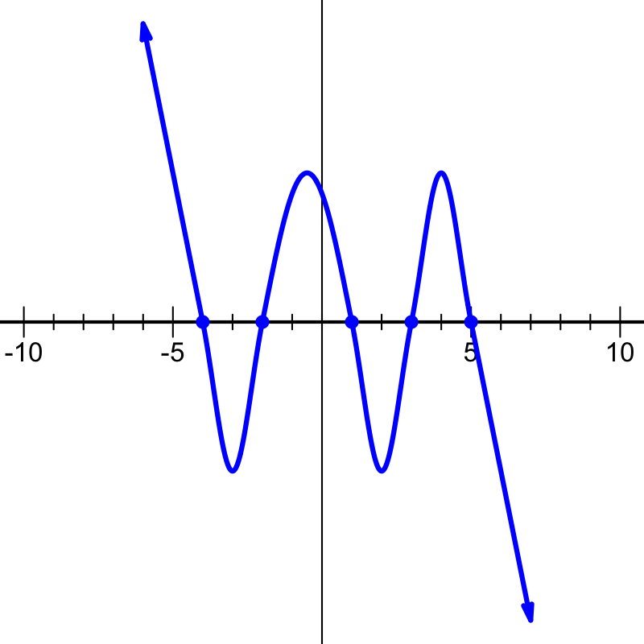

Which polynomial (in factored form) best matches the sketch?

$y=(x+5)(x+3)(x-2)(x-4)(x+1)$$y=-(x+5)(x+3)(x-2)(x-4)(x+1)$$y=-(x-5)(x-3)(x+2)(x+4)(x-1)$$y=(x-5)(x-3)(x+2)(x+4)(x-1)$

If a polynomial has a factor of $(x-r)$, then there will be an $x$-intercept at $(r,0)$.

In this case, the roots (the $x$-intercepts) are at:

$$-4,\,-2,\,1,\,3,\,5$$

Thus, the factors are $x+4$ and $x+2$ and $x-1$ and $x-3$ and $x-5$. So, we know that the function could be written as:

$$y=a(x+4)(x+2)(x-1)(x-3)(x-5)$$

where $a$ is some constant.

Lastly, we need to determine whether $a$ should be positive or negative. In this problem, either $a=1$ or $a=-1$. To determine this, look at the right side of the graph. Specifically, we are considering the [end behavior of polynomials](https://www.khanacademy.org/math/algebra2/x2ec2f6f830c9fb89:poly-graphs/x2ec2f6f830c9fb89:poly-end-behavior/a/end-behavior-of-polynomials). Notice that once $x$ is larger than $5$, all the factors will be positive, so only $a$ will dictate whether the function on the right side is positive or negative.

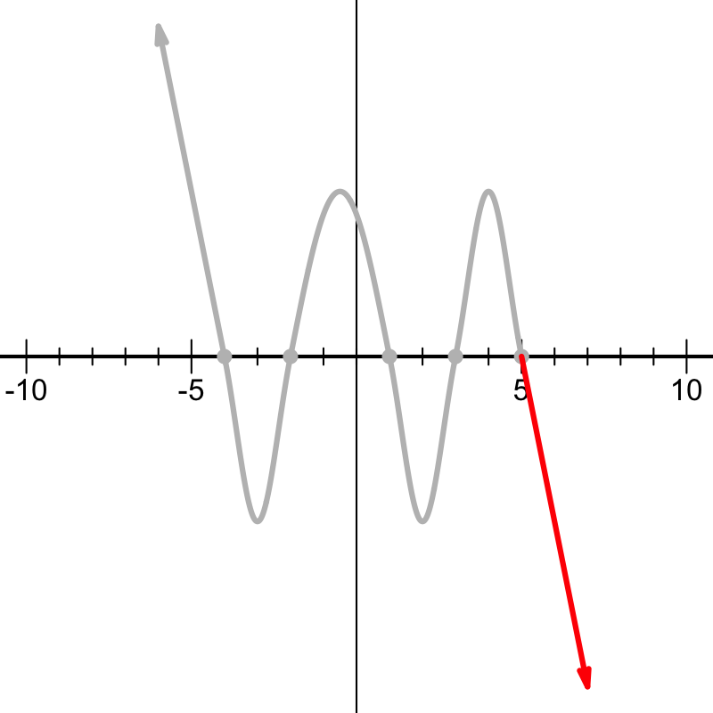

Notice, on the right side, the function is heading down. I guess more importantly, as $x\to \infty$ we see the function is negative. This implies that $a$ is negative. So, in this case, $a=-1$.

$$y=-(x+4)(x+2)(x-1)(x-3)(x-5)$$

And then, since multiplication is commutative, the factors can be written in any order. In this case, the correct answer is:

$$y=-(x-5)(x-3)(x+2)(x+4)(x-1)$$

A polynomial is sketched below.

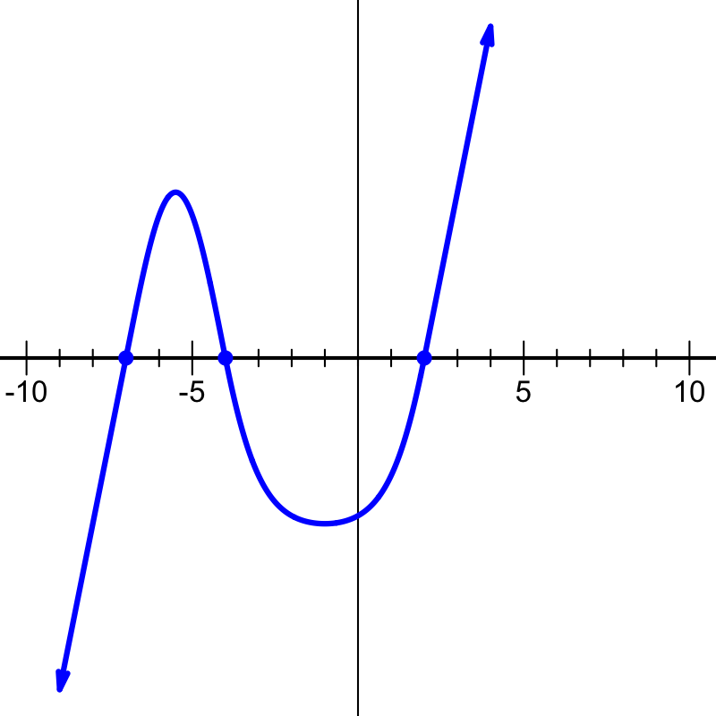

Which polynomial (in factored form) best matches the sketch?

$y=-(x-2)(x+4)(x+7)$$y=(x+2)(x-4)(x-7)$$y=-(x+2)(x-4)(x-7)$$y=(x-2)(x+4)(x+7)$

If a polynomial has a factor of $(x-r)$, then there will be an $x$-intercept at $(r,0)$.

In this case, the roots (the $x$-intercepts) are at:

$$-7,\,-4,\,2$$

Thus, the factors are $x+7$ and $x+4$ and $x-2$. So, we know that the function could be written as:

$$y=a(x+7)(x+4)(x-2)$$

where $a$ is some constant.

Lastly, we need to determine whether $a$ should be positive or negative. In this problem, either $a=1$ or $a=-1$. To determine this, look at the right side of the graph. Specifically, we are considering the [end behavior of polynomials](https://www.khanacademy.org/math/algebra2/x2ec2f6f830c9fb89:poly-graphs/x2ec2f6f830c9fb89:poly-end-behavior/a/end-behavior-of-polynomials). Notice that once $x$ is larger than $2$, all the factors will be positive, so only $a$ will dictate whether the function on the right side is positive or negative.

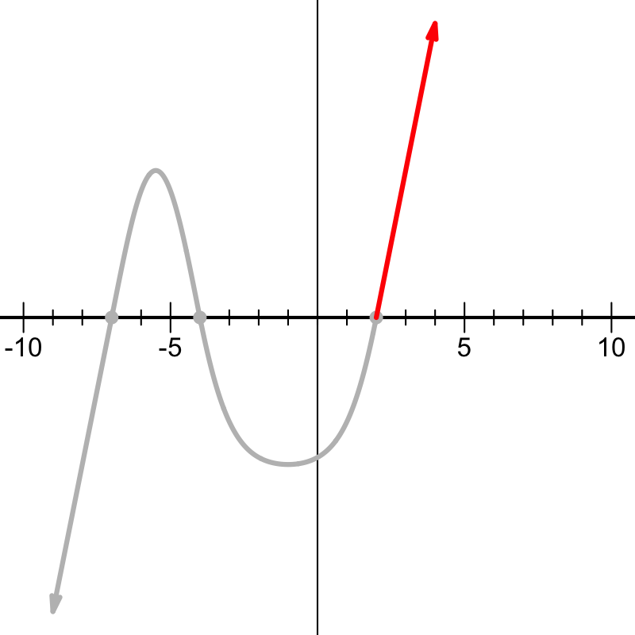

Notice, on the right side, the function is heading up. I guess more importantly, as $x\to \infty$ we see the function is positive. This implies that $a$ is positive. So, in this case, $a=1$.

$$y=(x+7)(x+4)(x-2)$$

And then, since multiplication is commutative, the factors can be written in any order. In this case, the correct answer is:

$$y=(x-2)(x+4)(x+7)$$

A polynomial is sketched below.

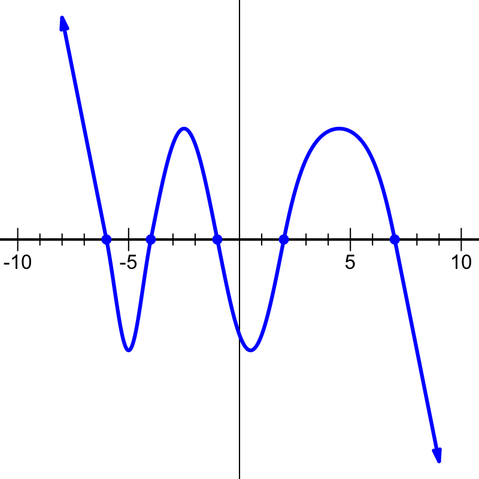

Which polynomial (in factored form) best matches the sketch?

$y=-(x-4)(x-6)(x+2)(x+7)(x-1)$$y=-(x+4)(x+6)(x-2)(x-7)(x+1)$$y=(x+4)(x+6)(x-2)(x-7)(x+1)$$y=(x-4)(x-6)(x+2)(x+7)(x-1)$

If a polynomial has a factor of $(x-r)$, then there will be an $x$-intercept at $(r,0)$.

In this case, the roots (the $x$-intercepts) are at:

$$-6,\,-4,\,-1,\,2,\,7$$

Thus, the factors are $x+6$ and $x+4$ and $x+1$ and $x-2$ and $x-7$. So, we know that the function could be written as:

$$y=a(x+6)(x+4)(x+1)(x-2)(x-7)$$

where $a$ is some constant.

Lastly, we need to determine whether $a$ should be positive or negative. In this problem, either $a=1$ or $a=-1$. To determine this, look at the right side of the graph. Specifically, we are considering the [end behavior of polynomials](https://www.khanacademy.org/math/algebra2/x2ec2f6f830c9fb89:poly-graphs/x2ec2f6f830c9fb89:poly-end-behavior/a/end-behavior-of-polynomials). Notice that once $x$ is larger than $7$, all the factors will be positive, so only $a$ will dictate whether the function on the right side is positive or negative.

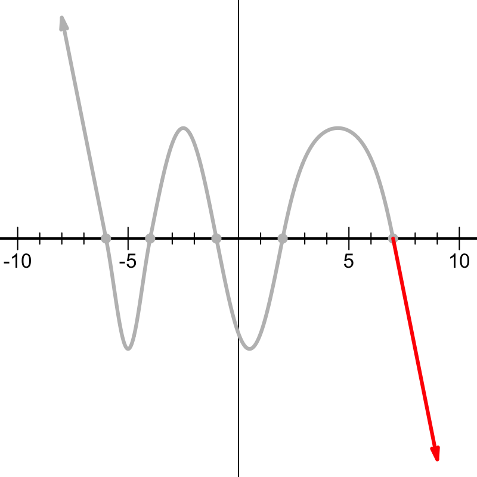

Notice, on the right side, the function is heading down. I guess more importantly, as $x\to \infty$ we see the function is negative. This implies that $a$ is negative. So, in this case, $a=-1$.

$$y=-(x+6)(x+4)(x+1)(x-2)(x-7)$$

And then, since multiplication is commutative, the factors can be written in any order. In this case, the correct answer is:

$$y=-(x+4)(x+6)(x-2)(x-7)(x+1)$$

A polynomial is sketched below.

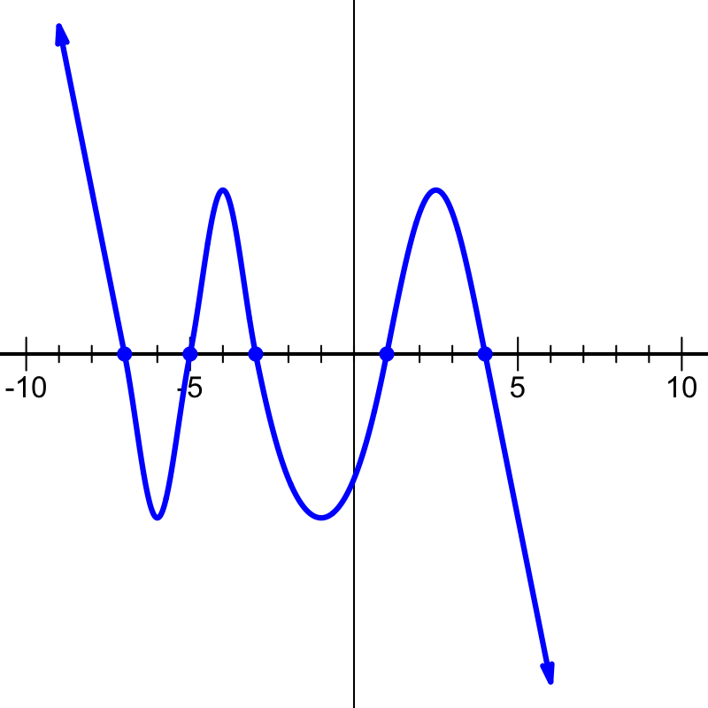

Which polynomial (in factored form) best matches the sketch?

$y=-(x+3)(x+5)(x-1)(x-4)(x+7)$$y=(x-3)(x-5)(x+1)(x+4)(x-7)$$y=(x+3)(x+5)(x-1)(x-4)(x+7)$$y=-(x-3)(x-5)(x+1)(x+4)(x-7)$

If a polynomial has a factor of $(x-r)$, then there will be an $x$-intercept at $(r,0)$.

In this case, the roots (the $x$-intercepts) are at:

$$-7,\,-5,\,-3,\,1,\,4$$

Thus, the factors are $x+7$ and $x+5$ and $x+3$ and $x-1$ and $x-4$. So, we know that the function could be written as:

$$y=a(x+7)(x+5)(x+3)(x-1)(x-4)$$

where $a$ is some constant.

Lastly, we need to determine whether $a$ should be positive or negative. In this problem, either $a=1$ or $a=-1$. To determine this, look at the right side of the graph. Specifically, we are considering the [end behavior of polynomials](https://www.khanacademy.org/math/algebra2/x2ec2f6f830c9fb89:poly-graphs/x2ec2f6f830c9fb89:poly-end-behavior/a/end-behavior-of-polynomials). Notice that once $x$ is larger than $4$, all the factors will be positive, so only $a$ will dictate whether the function on the right side is positive or negative.

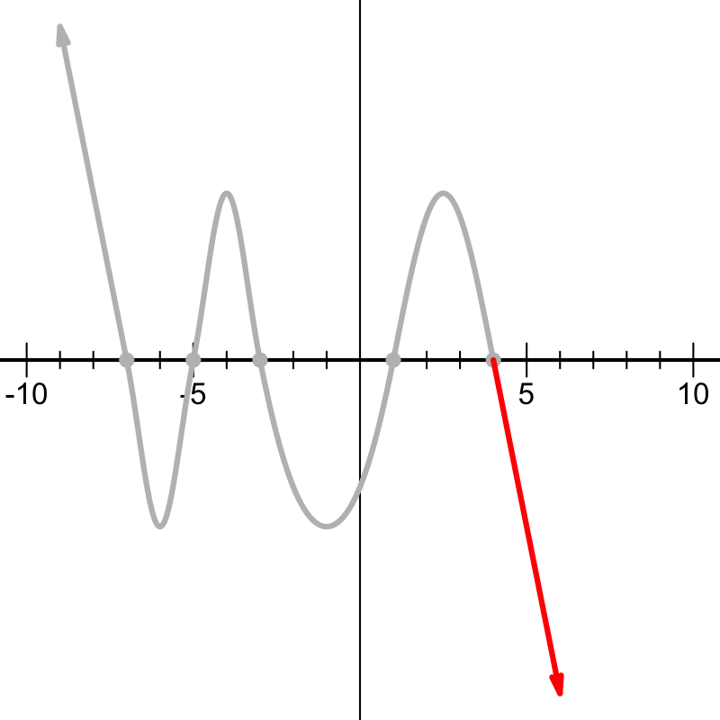

Notice, on the right side, the function is heading down. I guess more importantly, as $x\to \infty$ we see the function is negative. This implies that $a$ is negative. So, in this case, $a=-1$.

$$y=-(x+7)(x+5)(x+3)(x-1)(x-4)$$

And then, since multiplication is commutative, the factors can be written in any order. In this case, the correct answer is:

$$y=-(x+3)(x+5)(x-1)(x-4)(x+7)$$

A polynomial is sketched below.

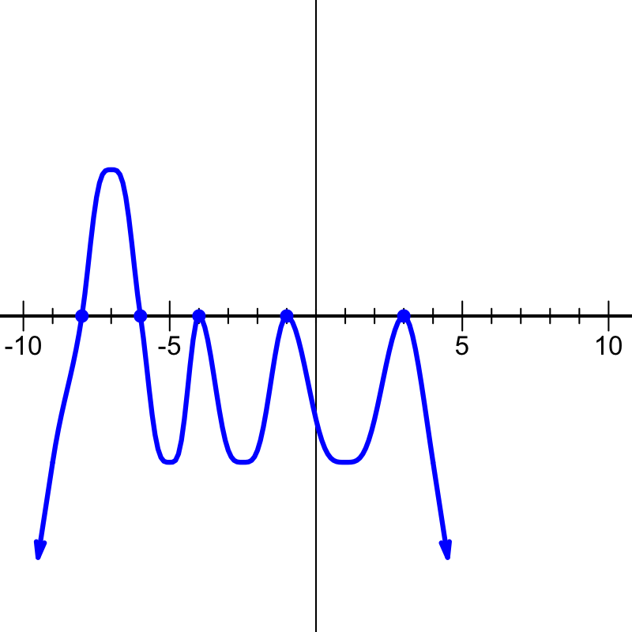

Which polynomial (in factored form) best matches the sketch?

$y=-(x+6)^2(x+1)(x+8)^2(x+4)(x-3)^2$$y=(x+6)(x+1)^2(x+8)(x+4)^2(x-3)^2$$y=-(x+6)(x+1)^2(x+8)(x+4)^2(x-3)^2$$y=(x+6)^2(x+1)(x+8)^2(x+4)(x-3)^2$

If a polynomial has a factor of $x-r$, then there will be an $x$-intercept at point $(r,0)$.

In this case, the roots (the $x$-intercepts) are at:

$$-8,\,-6,\,-4,\,-1,\,3$$

Thus, the factors are $x+8$ and $x+6$ and $x+4$ and $x+1$ and $x-3$. Notice, the $x$-intercepts where the curve "bounces" off the $x$ axis correspond to an even multiplicity, in this case a multiplicity of 2. So, we know the curve could be represented by the function below:

$$y=a(x+8)(x+6)(x+4)^2(x+1)^2(x-3)^2$$

where $a$ is some constant.

Lastly, we need to determine whether $a$ should be positive or negative. In this problem, either $a=1$ or $a=-1$. To determine this, look at the right side of the graph. Specifically, we are considering the [end behavior of polynomials](https://www.khanacademy.org/math/algebra2/x2ec2f6f830c9fb89:poly-graphs/x2ec2f6f830c9fb89:poly-end-behavior/a/end-behavior-of-polynomials). Notice that once $x$ is larger than $3$, all the factors will be positive, so only $a$ will dictate whether the function on the right side is positive or negative.

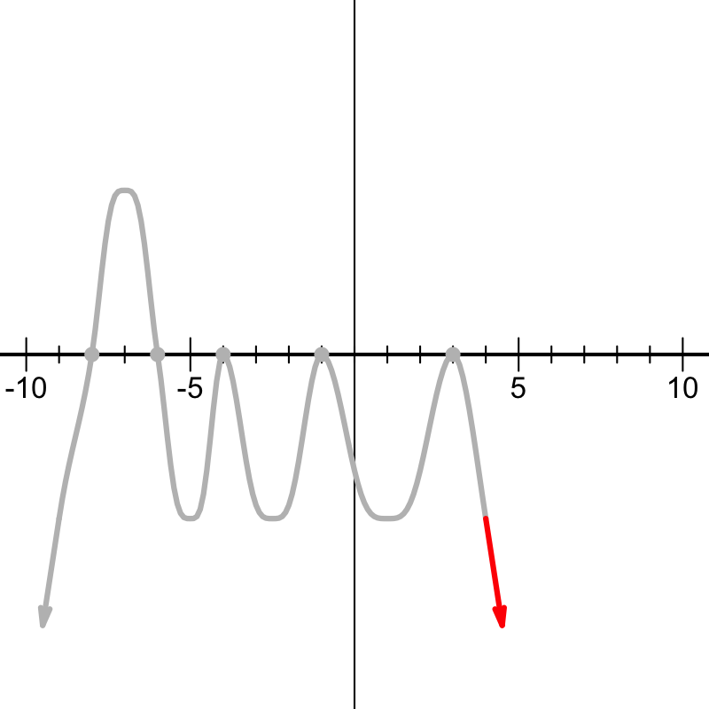

Notice, on the right side, the function is heading down. I guess more importantly, as $x\to \infty$ we see the function is negative. This implies that $a$ is negative. So, in this case, $a=-1$.

$$y=-(x+8)(x+6)(x+4)^2(x+1)^2(x-3)^2$$

And then, since multiplication is commutative, the factors can be written in any order. In this case, the correct answer is:

$$y=-(x+6)(x+1)^2(x+8)(x+4)^2(x-3)^2$$

A polynomial is sketched below.

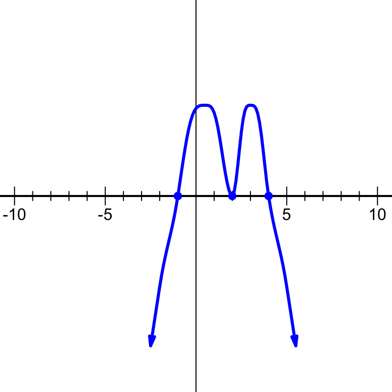

Which polynomial (in factored form) best matches the sketch?

$y=(x-2)(x-4)^2(x+1)^2$$y=-(x-2)(x-4)^2(x+1)^2$$y=(x-2)^2(x-4)(x+1)$$y=-(x-2)^2(x-4)(x+1)$

If a polynomial has a factor of $x-r$, then there will be an $x$-intercept at point $(r,0)$.

In this case, the roots (the $x$-intercepts) are at:

$$-1,\,2,\,4$$

Thus, the factors are $x+1$ and $x-2$ and $x-4$. Notice, the $x$-intercepts where the curve "bounces" off the $x$ axis correspond to an even multiplicity, in this case a multiplicity of 2. So, we know the curve could be represented by the function below:

$$y=a(x+1)(x-2)^2(x-4)$$

where $a$ is some constant.

Lastly, we need to determine whether $a$ should be positive or negative. In this problem, either $a=1$ or $a=-1$. To determine this, look at the right side of the graph. Specifically, we are considering the [end behavior of polynomials](https://www.khanacademy.org/math/algebra2/x2ec2f6f830c9fb89:poly-graphs/x2ec2f6f830c9fb89:poly-end-behavior/a/end-behavior-of-polynomials). Notice that once $x$ is larger than $4$, all the factors will be positive, so only $a$ will dictate whether the function on the right side is positive or negative.

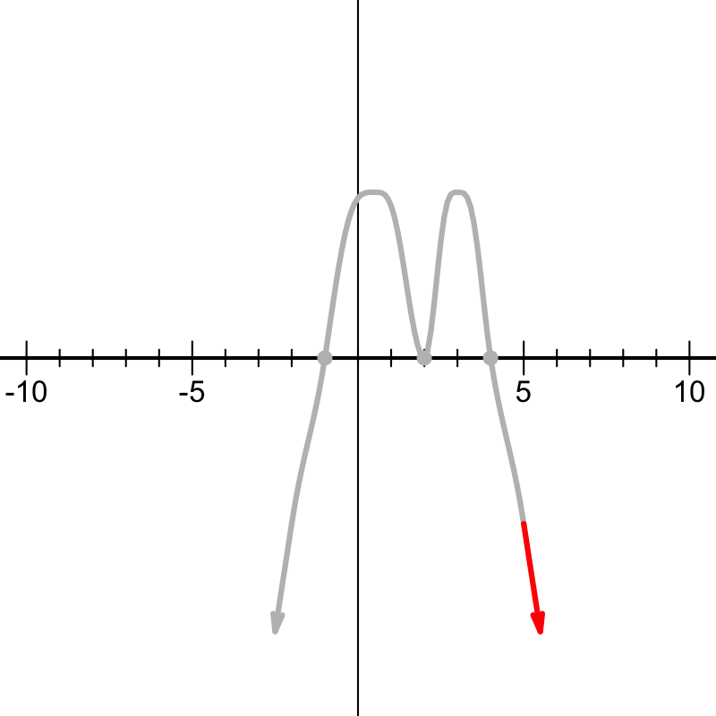

Notice, on the right side, the function is heading down. I guess more importantly, as $x\to \infty$ we see the function is negative. This implies that $a$ is negative. So, in this case, $a=-1$.

$$y=-(x+1)(x-2)^2(x-4)$$

And then, since multiplication is commutative, the factors can be written in any order. In this case, the correct answer is:

$$y=-(x-2)^2(x-4)(x+1)$$

A polynomial is sketched below.

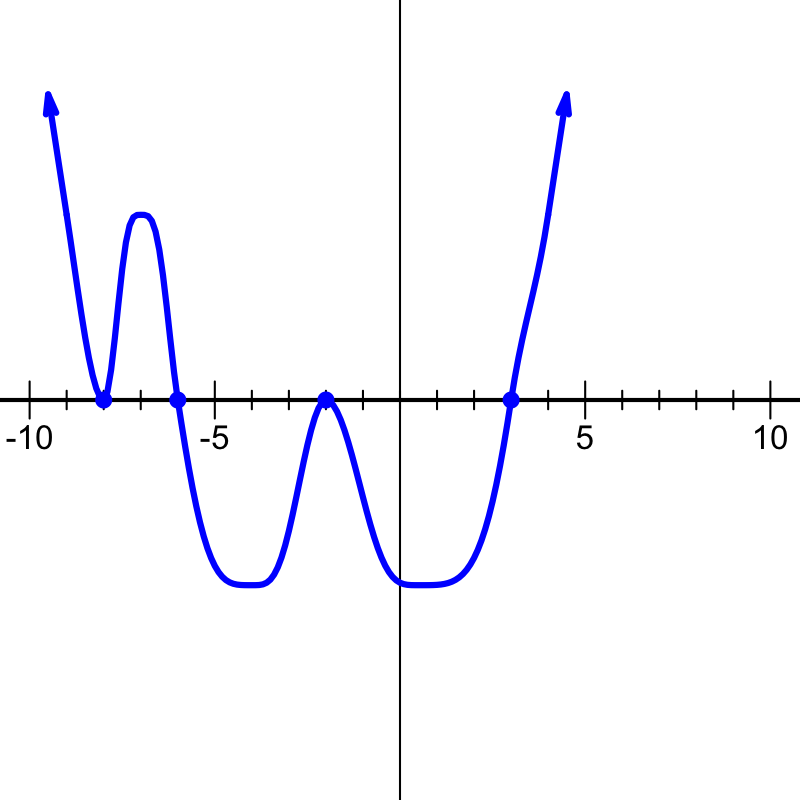

Which polynomial (in factored form) best matches the sketch?

$y=-(x+6)(x+8)^2(x+2)^2(x-3)$$y=(x+6)(x+8)^2(x+2)^2(x-3)$$y=(x+6)(x+8)(x+2)(x-3)^2$$y=-(x+6)(x+8)(x+2)(x-3)^2$

If a polynomial has a factor of $x-r$, then there will be an $x$-intercept at point $(r,0)$.

In this case, the roots (the $x$-intercepts) are at:

$$-8,\,-6,\,-2,\,3$$

Thus, the factors are $x+8$ and $x+6$ and $x+2$ and $x-3$. Notice, the $x$-intercepts where the curve "bounces" off the $x$ axis correspond to an even multiplicity, in this case a multiplicity of 2. So, we know the curve could be represented by the function below:

$$y=a(x+8)^2(x+6)(x+2)^2(x-3)$$

where $a$ is some constant.

Lastly, we need to determine whether $a$ should be positive or negative. In this problem, either $a=1$ or $a=-1$. To determine this, look at the right side of the graph. Specifically, we are considering the [end behavior of polynomials](https://www.khanacademy.org/math/algebra2/x2ec2f6f830c9fb89:poly-graphs/x2ec2f6f830c9fb89:poly-end-behavior/a/end-behavior-of-polynomials). Notice that once $x$ is larger than $3$, all the factors will be positive, so only $a$ will dictate whether the function on the right side is positive or negative.

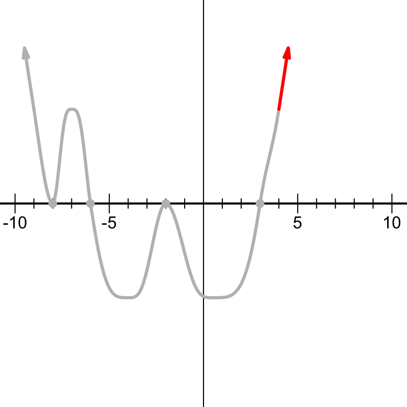

Notice, on the right side, the function is heading up. I guess more importantly, as $x\to \infty$ we see the function is positive. This implies that $a$ is positive. So, in this case, $a=1$.

$$y=(x+8)^2(x+6)(x+2)^2(x-3)$$